# HeatingRatesFullCode

Authors removed for double-blind review

12/01/2022

# Introduction

In this document we tested if the optical properties of Christmas Beetles can predict the heating of their elytra due to radiative heat in different stepectral bands (TOTAL: 400 to 1700nm, NIR: 700 to 1700 nm, VIS: 400 to 700 nm). We also tested if the presence of the elytra closed on top of the body can help reducing the heating rate of the beetle body.

We first processed the raw spectral data (reflectance and transmittance) and combined it with the irradiance spectra of the light source to obtain the values of reflectivity, transmissivity and absorptivity for each beetle in our sample (n=56 elytra representing 28 species of Christmas beetles)

Then we processed the heating raw data to obtain the total change in temperature after 5 minutes, and the maximum heating rate under each illumination (TOTAL, NIR and VIS).

For the single elytra experiments we used linear models and correlations to explore the relation between the optical properties and the two heating variables. For the beetle body experiments we used a bootstrap paired test to determine if the body of a recently dead beetle has a higher change in temperature when the elytra are open than when they are closed.

We provide details on data processing, statistical analysis and figures of the original manuscript submitted for peer review.

The following code is written in the R programming language.

The .Rmd file and Raw data can be found here: https://bit.ly/3OeBNU6 (This link contains information that may disclose author’s identity)

# Libraries

## Install packages

```r
install.packages("ggplot2") # graphs

install.packages("wesanderson") # Colour palette

install.packages("gridExtra") # basic to combine multiple ggplot

install.packages("rptR") # Repeatability analysis

install.packages("cowplot") # ggplot graphs alignment

install.packages("rsq") # Partial coeficients in the linear models

install.packages("pavo") # Processing spectral data

install.packages("dplyr") # Data wrangling

install.packages("jtools") # Reporting Results from Linear Models

install.packages("huxtable") # Reporting Results from Linear Models

install.packages("kableExtra") # To style tables in the HTML file
```

## Load packages

```r
library(ggplot2)
library(wesanderson)
library(gridExtra)
library(rptR)
library(cowplot)
library(rsq)
library(pavo)
library(tidyverse)
library(dplyr)
library(readr)
library(jtools)
library(huxtable)
library(kableExtra)
```

# Data Sets

## Raw Data

### Spectral Data

```r
# Reflectance
Reflect<-read.csv("../Data/1_Reflectancedata.csv") %>%
  as.rspec(.) %>%
  procspec(.,fixneg = "zero")

# Transmittance
TopTrans<-read.csv("../Data/2_Transmittancetopdata.csv") %>%
  filter (wl <= 1700 & wl >= 400) %>%
  as.rspec(.) %>%
  procspec(.,fixneg = "zero")

BotTrans<-read.csv("../Data/3_Transmittanceventraldata.csv") %>%
  filter (wl <= 1700 & wl >= 400) %>%
  as.rspec(.) %>%
  procspec(.,fixneg = "zero")

# Solar Simulator and Filters
filters<-read.csv("../Data/4_SolarSimulatorAndFilters.csv") %>%
  as.rspec(.) %>%
  procspec(.,fixneg = "zero")

# Solar Irradiance
theorySun<-read.csv("../Data/5_TheoreticalIrradiance.csv") %>%
  as.rspec(.) %>%
  procspec(.,fixneg = "zero")
```

### Heating Rates Data

Note: This data frame has been revised to ensure the alignment in times is correct for all species (columns)

```r
TempRaw <- read.csv ("../Data/6_SingleElytronTempDataRaw.csv")

BodyRaw <- read.csv ("../Data/8_BeetleBodyTempDataRaw.csv")
```

### Others

This data set includes information as species, batch (for repeatability or for the experiment), size and side of the platform

```r
Other <- read.csv ("../Data/7_SizeAndSide.csv")
```

This data set is an example of the raw temperature data obtained by the thermometer:

```r
Setup <- read.csv("../Data/9_ExampleSetup.csv")
```

## Data Processing

### Optical Properties

#### Reflectivity

##### Add filters

```r
### One data frame for Total spectrum
forTOT<-Reflect
forTOT$irr<-filters$Full.f

### One data frame for NIR
forNIR<-Reflect
forNIR$irr<-filters$nir.f

### One data frame for vis
forVIS<-Reflect
forVIS$irr<-filters$vis.f
```

##### Multiplication function

```r
# Define the following function to find the multiplication

Find.multiplication<-function(s){
  vector2<-rep("NA", length(s[ , 1]))
  for( i in 2 : length(s) - 1){
    for (y in 1 : length(s[ , 1])){
      vector2[y] <- s[y, i] * s[y, "irr"] # multiply each column by the last one
    }
    s[i] <- as.numeric(vector2)
  }
  return(s)
}
```

##### Apply

```r
# Total spectrum
PrelValReflTOT <-
  forTOT %>%
  Find.multiplication(.) %>% # Apply function
  select (-wl, # the wavelengths were altered, eliminate
          -irr) %>% # irradiance not required anymore, eliminate
  mutate (wl = Reflect$wl) %>%  # add the correct wavelength column
  select(wl, everything()) %>% # set the wl column as column 1
  as.rspec(.) # convert to rspec object


# NIR

PrelValReflNIR <-
  forNIR %>%   # Change data frame for NIR
  Find.multiplication(.) %>%
  select (-wl,
          -irr) %>%
  mutate (wl = Reflect$wl) %>%
  select(wl, everything()) %>%
  as.rspec(.)


# VIS

PrelValReflVIS <-
  forVIS %>%  # Change data frame for VIS
  Find.multiplication(.) %>%
  select (-wl,
          -irr) %>%
  mutate (wl = Reflect$wl) %>%
  select(wl, everything()) %>%
  as.rspec(.)
```

##### Calculate AUC

Area under the curve

```r
# Calculate AUC for preliminary values of the samples

r.TOT <- summary(PrelValReflTOT)$B1
r.NIR <- summary(PrelValReflNIR)$B1
r.VIS <- summary(PrelValReflVIS)$B1

# Calculate AUC for the filters

AUCsun <- summary(filters[,c(1,5)])$B1 # Portal open -  full spectrum
AUCnir <- summary(filters[,c(1,7)])$B1 # When using filter to let pass NIR
AUCvis <- summary(filters[,c(1,6)])$B1 # When using filter to let pass vis
```

##### Standardise

```r
Reflectivity<-data.frame("spp" = names(Reflect[2:57]),
                         "FUL" = r.TOT / AUCsun,
                         "NIR" = r.NIR / AUCnir,
                         "VIS" = r.VIS / AUCvis)
Reflectivity <-
  Reflectivity %>%
  arrange (spp)
```

#### Transmissivity

##### Add filters

```r
### One data frame for Total spectrum
TforTOT <- TopTrans
TforTOT$irr <- filters$Full.f

### One data frame for NIR
TforNIR <- TopTrans
TforNIR$irr <- filters$nir.f

### One data frame for vis
TforVIS <- TopTrans
TforVIS$irr <- filters$vis.f
```

##### Multiplication function

```r
# Define the following function to find the multiplication

Find.multiplication<-function(s){
  vector2<-rep("NA", length(s[ , 1]))
  for( i in 2 : length(s) - 1){
    for (y in 1 : length(s[ , 1])){
      vector2[y] <- s[y, i] * s[y, "irr"] # multiply each column by the last one
    }
    s[i] <- as.numeric(vector2)
  }
  return(s)
}

# This is the same function as the one in reflectivity
```

##### Apply

```r
# Total spectrum
PrelValTransTOT <-
  TforTOT %>%
  Find.multiplication(.) %>% # Apply function
  select (-wl, # the wavelengths were altered, eliminate
          -irr) %>% # irradiance not required anymore, eliminate
  mutate (wl = Reflect$wl) %>%  # add the correct wavelength column
  select(wl, everything()) %>% # set the wl column as column 1
  as.rspec(.) # convert to rspec object


# NIR

PrelValTransNIR <-
  TforNIR %>%   # Change data frame for NIR
  Find.multiplication(.) %>%
  select (-wl,
          -irr) %>%
  mutate (wl = Reflect$wl) %>%
  select(wl, everything()) %>%
  as.rspec(.)


# VIS

PrelValTransVIS <-
  TforVIS %>%  # Change data frame for VIS
  Find.multiplication(.) %>%
  select (-wl,
          -irr) %>%
  mutate (wl = Reflect$wl) %>%
  select(wl, everything()) %>%
  as.rspec(.)
```

##### Calculate AUC

Area under the curve

```r
# Calculate AUC for preliminary values of the samples

t.TOT <- summary(PrelValTransTOT)$B1
t.NIR <- summary(PrelValTransNIR)$B1
t.VIS <- summary(PrelValTransVIS)$B1

# Calculate AUC for the filters (same as reflectivity)

AUCsun <- summary(filters[,c(1,5)])$B1 # Portal open -  full spectrum
AUCnir <- summary(filters[,c(1,7)])$B1 # When using filter to let pass NIR
AUCvis <- summary(filters[,c(1,6)])$B1 # When using filter to let pass vis
```

##### Standardise

```r
Transmissivity<-data.frame("spp" = names(TopTrans[2:57]),
                         "FUL" = t.TOT / AUCsun,
                         "NIR" = t.NIR / AUCnir,
                         "VIS" = t.VIS / AUCvis)
Transmissivity <-
  Transmissivity %>%
  arrange (spp)
```

#### Ventral Transmissivity

##### Add filters

```r
### One data frame for Total spectrum
TVforTOT <- BotTrans
TVforTOT$irr <- filters$Full.f

### One data frame for NIR
TVforNIR <- BotTrans
TVforNIR$irr <- filters$nir.f

### One data frame for vis
TVforVIS <- BotTrans
TVforVIS$irr <- filters$vis.f
```

##### Multiplication function

```r
# Define the following function to find the multiplication

Find.multiplication<-function(s){
  vector2<-rep("NA", length(s[ , 1]))
  for( i in 2 : length(s) - 1){
    for (y in 1 : length(s[ , 1])){
      vector2[y] <- s[y, i] * s[y, "irr"] # multiply each column by the last one
    }
    s[i] <- as.numeric(vector2)
  }
  return(s)
}

# This is the same function as the one in reflectivity
```

##### Apply

```r
# Total spectrum
PrelValTransVentTOT <-
  TVforTOT %>%
  Find.multiplication(.) %>% # Apply function
  select (-wl, # the wavelengths were altered, eliminate
          -irr) %>% # irradiance not required anymore, eliminate
  mutate (wl = Reflect$wl) %>%  # add the correct wavelength column
  select(wl, everything()) %>% # set the wl column as column 1
  as.rspec(.) # convert to rspec object


# NIR

PrelValTransVentNIR <-
  TVforNIR %>%   # Change data frame for NIR
  Find.multiplication(.) %>%
  select (-wl,
          -irr) %>%
  mutate (wl = Reflect$wl) %>%
  select(wl, everything()) %>%
  as.rspec(.)


# VIS

PrelValTransVentVIS <-
  TVforVIS %>%  # Change data frame for VIS
  Find.multiplication(.) %>%
  select (-wl,
          -irr) %>%
  mutate (wl = Reflect$wl) %>%
  select(wl, everything()) %>%
  as.rspec(.)
```

##### Calculate AUC

Area under the curve

```r
# Calculate AUC for preliminary values of the samples

t.v.TOT <- summary(PrelValTransVentTOT)$B1
t.v.NIR <- summary(PrelValTransVentNIR)$B1
t.v.VIS <- summary(PrelValTransVentVIS)$B1

# Calculate AUC for the filters (same as reflectivity)

AUCsun <- summary(filters[,c(1,5)])$B1 # Portal open -  full spectrum
AUCnir <- summary(filters[,c(1,7)])$B1 # When using filter to let pass NIR
AUCvis <- summary(filters[,c(1,6)])$B1 # When using filter to let pass vis
```

##### Standardise

```r
Transmiss.Ventral<-data.frame("spp" = names(BotTrans[2:57]),
                         "FUL" = t.v.TOT / AUCsun,
                         "NIR" = t.v.NIR / AUCnir,
                         "VIS" = t.v.VIS / AUCvis)
Transmiss.Ventral <-
  Transmiss.Ventral %>%
  arrange (spp)
```

#### Consolidated

In this step we calculated absorptivity as 100 - (Reflectivity + transmissivity)

```r
Optical <-
  data.frame (Reflectivity,
              Transmissivity,
              Transmiss.Ventral) %>%
  select (-spp.1, -spp.2)

names(Optical) <- c( "spp",
                     "Rf_TOT", "Rf_NIR", "Rf_VIS", # Reflectivity
                     "Td_TOT", "Td_NIR", "Td_VIS", # Dorsal Transmissivity
                     "Tv_TOT", "Tv_NIR", "Tv_VIS") # Ventral Transmissivity

Optical <-
  Optical %>%
  mutate (DifferenceTransTOT = (Tv_TOT - Td_TOT) / Td_TOT * 100,
          DifferenceTransNIR = (Tv_NIR - Td_NIR) / Td_NIR * 100,
          DifferenceTransVIS = (Tv_VIS - Td_VIS) / Td_VIS * 100
          ) %>% # Percentaages Difference between dorsal and ventral
  mutate (Ab_TOT = 100 - (Rf_TOT + Td_TOT),
          Ab_NIR = 100 - (Rf_NIR + Td_NIR),
          Ab_VIS = 100 - (Rf_VIS + Td_VIS)) # Calculate Absorptivity
```

### Heating

#### Single Elytra

##### Delta temp after 5 min

```r
ind <- (names(TempRaw)[3:96])

t0TOT <-
  TempRaw %>%
  filter (time == 280) %>%  # t0 time
  select (-light, -time) %>%
  as.numeric (.)

tfTOT <-
  TempRaw %>%
  filter (time == 580) %>% # end time of the first illumination
  select (-light, -time) %>%
  as.numeric (.)

t0NIR <-
  TempRaw %>%
  filter (time == 880) %>%  # t0 time
  select (-light, -time) %>%
  as.numeric (.)

tfNIR <-
  TempRaw %>%
  filter (time == 1180) %>% # end time of the first illumination
  select (-light, -time) %>%
  as.numeric (.)

t0VIS <-
  TempRaw %>%
  filter (time == 1480) %>%  # t0 time
  select (-light, -time) %>%
  as.numeric (.)

tfVIS <-
  TempRaw %>%
  filter (time == 1780) %>% # end time of the first illumination
  select (-light, -time) %>%
  as.numeric (.)


TimePoints <- data.frame( ind, t0TOT, tfTOT, t0NIR, tfNIR, t0VIS, tfVIS )

DeltaT5 <-
  TimePoints %>%
  mutate (
    DT5_TOT = tfTOT - t0TOT,
    DT5_NIR = tfNIR - t0NIR,
    DT5_VIS = tfVIS - t0VIS ) %>%
  select (1,8,9,10) %>%
  arrange (ind)
```

##### Max Heating Rates

Calculated as the max. slope in degrees celsius / sec. Max. change in a 20 sec interval divided by 20

```r
# TOTA LIGHT (nir + vis)

# Prepare subset
SlopesTOT2 <-
  TempRaw %>%
  select (-light) %>%  # remove the column "light"
  filter (time >= 300 & time <= 600) %>%  # keep the interval with the light on
  select (-time) %>%
  select (sort(colnames(.)))

SlopesTOT <- SlopesTOT2 # rename because it will be overwritten by the function

# Run this function to find the slope for each 20 sec

for (i in 1: length (SlopesTOT)) { # for each column
  for (ii in 2: length (SlopesTOT[,i])){ # take each value (start in the second)
    SlopesTOT [ii-1,i] <- # overwrite the previous value with the result
      (abs( (SlopesTOT[ii-1,i]) - (SlopesTOT[(ii),i])))/ 20 # divide by 20
    }
  }

SlopesTOT <- SlopesTOT[1:15,] # Remove last value. it does not contain result

# Run this function to find the max slope

maxHRTOT <- rep("NA",length(SlopesTOT)) # empty vector
for (i in 1: length (SlopesTOT)) { # for each column in the data frame
  maxHRTOT[i]<-round(max(as.numeric(SlopesTOT[,i])),3) # find the max value
}


# NIR

# Prepare subset
SlopesNIR2 <-
  TempRaw %>%
  select (-light) %>%  # remove the column "light"
  filter (time >= 900 & time <= 1200) %>%  # keep the interval with NIR
  select (-time) %>%
  select (sort(colnames(.)))

SlopesNIR <- SlopesNIR2 # rename

# Run this function to find the slope for each 20 sec

for (i in 1: length (SlopesNIR)) {
  for (ii in 2: length (SlopesNIR[,i])){
    SlopesNIR [ii-1,i] <-
      (abs( (SlopesNIR[ii-1,i]) - (SlopesNIR[(ii),i])))/ 20
    }
  }

SlopesNIR <- SlopesNIR[1:15,] # Remove last value.

# Run this function to find the max slope

maxHRNIR <- rep("NA",length(SlopesNIR))
for (i in 1: length (SlopesNIR)) {
  maxHRNIR[i]<-round(max(as.numeric(SlopesNIR[,i])),3)
}


# VIS

# Prepare subset
SlopesVIS2 <-
  TempRaw %>%
  select (-light) %>%  # remove the column "light"
  filter (time >= 1500 & time <= 1800) %>%  # keep the interval with VIS
  select (-time) %>%
  select (sort(colnames(.)))

SlopesVIS <- SlopesVIS2 # rename

# Run this function to find the slope for each 20 sec

for (i in 1: length (SlopesVIS)) {
  for (ii in 2: length (SlopesVIS[,i])){
    SlopesVIS [ii-1,i] <-
      (abs( (SlopesVIS[ii-1,i]) - (SlopesVIS[(ii),i])))/ 20
    }
  }

SlopesVIS <- SlopesVIS[1:15,] # Remove last value.

# Run this function to find the max slope

maxHRVIS <- rep("NA",length(SlopesVIS))
for (i in 1: length (SlopesVIS)) {
  maxHRVIS[i]<-round(max(as.numeric(SlopesVIS[,i])),3)
}


# COMBINE

maxHR <- data.frame (
  "ind" = names(SlopesTOT2),
  maxHRTOT = as.numeric(maxHRTOT),
  maxHRNIR = as.numeric(maxHRNIR),
  maxHRVIS = as.numeric(maxHRVIS))
```

##### Consolidated

```r
HeatData <- data.frame (Other, DeltaT5, maxHR) %>%
  select(-ind.1, -ind.2) %>%
  select(ind, spp, genus,
         batch, Thermocouple, side,
         size, everything())

Repeatability <-
  HeatData %>%
  filter (batch == "repeatability" | batch == "both") %>%
  arrange (ind)

SingleElytra <-
  HeatData %>%
  filter (batch == "experiment" | batch == "both") %>%
  arrange (ind)
```

#### Beetle Body

##### Delta temp after 5 min

In this case, the time to cool down between treatments was double due to a higer mass

```r
codexp <- (names(BodyRaw)[3:length(BodyRaw)])

B_t0TOT <-
  BodyRaw %>%
  filter (time == 280) %>%  # t0 time
  select (-light, -time) %>%
  as.numeric (.)

B_tfTOT <-
  BodyRaw %>%
  filter (time == 580) %>% # end time of the first illumination
  select (-light, -time) %>%
  as.numeric (.)

B_t0NIR <-
  BodyRaw %>%
  filter (time == 1180) %>%  # t0 time
  select (-light, -time) %>%
  as.numeric (.)

B_tfNIR <-
  BodyRaw %>%
  filter (time == 1480) %>% # end time of the first illumination
  select (-light, -time) %>%
  as.numeric (.)

B_t0VIS <-
  BodyRaw %>%
  filter (time == 2080) %>%  # t0 time
  select (-light, -time) %>%
  as.numeric (.)

B_tfVIS <-
  BodyRaw %>%
  filter (time == 2380) %>% # end time of the first illumination
  select (-light, -time) %>%
  as.numeric (.)


B_TimePoints <- data.frame( codexp,
                          B_t0TOT, B_tfTOT,
                          B_t0NIR, B_tfNIR,
                          B_t0VIS, B_tfVIS )

BodyDeltaT5 <-
  B_TimePoints %>%
  mutate (
    B_DT5_TOT = B_tfTOT - B_t0TOT,
    B_DT5_NIR = B_tfNIR - B_t0NIR,
    B_DT5_VIS = B_tfVIS - B_t0VIS ) %>%
  select (1,8,9,10) %>%
  arrange (codexp) %>%
  separate (codexp, sep = 5, c("Beetle","conditions")) %>%
  separate (conditions, sep = 1, c("Thermocouple", "ElytraPosition"))
```

##### Consolidated

Reorder the data frame to find the difference between elytra open and closed

```r
# "e" = Thermocouple under the elytra
# "i" = Thermocouple inside the body
# "c" =  elytra closed
# "o" =  elytra open

# Thermocouple outside the body, right under the elytra:
DT5_ThermoExt <-
  BodyDeltaT5 %>%
  filter (Thermocouple == "e") %>% # Keep only: thermocouple external
  select (-Thermocouple) %>%  # column not needed anymore
  gather (SpectralBand, DT5, starts_with("B_")) %>% # column for spectral band
  unite (Var1, SpectralBand, ElytraPosition) %>% # fuse spectral band + Elytra
  spread (Var1, DT5) %>%  # obtain one col for open and close at each band
  mutate (
    PairDifTOT = round (( B_DT5_TOT_c - B_DT5_TOT_o),4),
    PairDifNIR = round (( B_DT5_NIR_c - B_DT5_NIR_o),4),
    PairDifVIS = round (( B_DT5_VIS_c - B_DT5_VIS_o),4)
  ) %>% # Find paired difference for each band. Elytra closed - open
  select (1, 8:10) # Keep only the differences


DT5_ThermoInt <-
  BodyDeltaT5 %>%
  filter (Thermocouple == "i") %>%  # Keep only: thermocouple internal
  select (-Thermocouple) %>%
  gather (SpectralBand, DT5, starts_with("B_")) %>% # column for spectral band
  unite (Var1, SpectralBand, ElytraPosition) %>% # fuse spectral band + Elytra
  spread (Var1, DT5) %>%  # obtain one col for open and close at each band
  mutate (
    PairDifTOT = round (( B_DT5_TOT_c - B_DT5_TOT_o),4),
    PairDifNIR = round (( B_DT5_NIR_c - B_DT5_NIR_o),4),
    PairDifVIS = round (( B_DT5_VIS_c - B_DT5_VIS_o),4)
  ) %>% # Find paired difference for each band. Elytra closed - open
  select (1, 8:10) # Keep only the differences

BodyData <- data.frame (DT5_ThermoExt, DT5_ThermoInt)
```

# Experimental Set up

## Figure 1

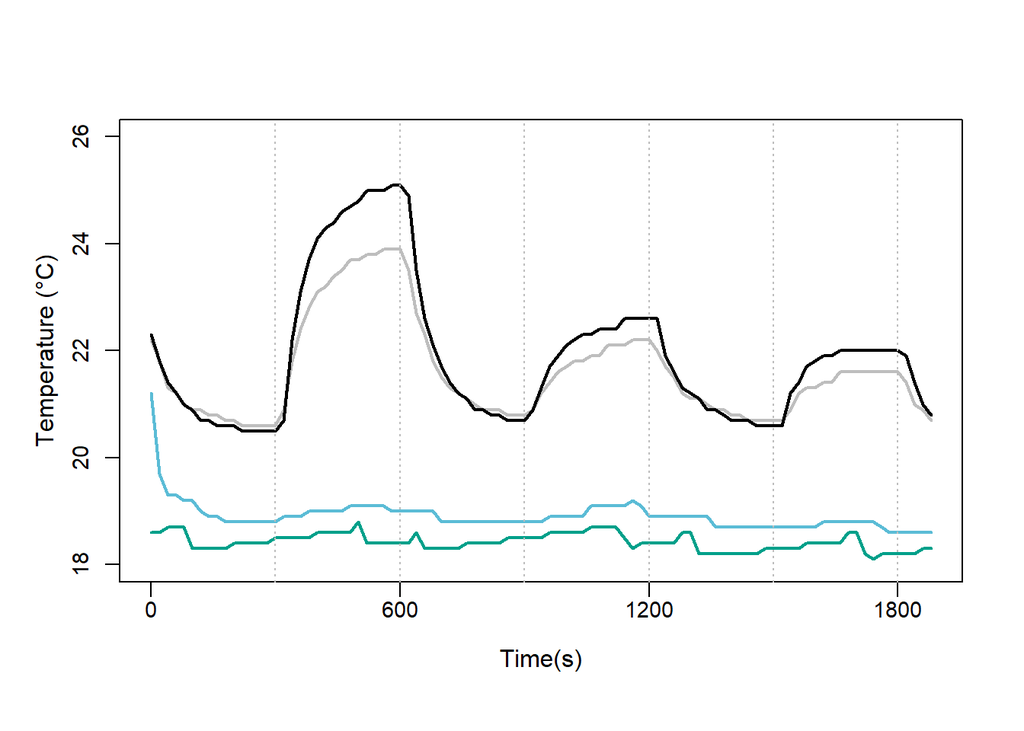

```r
setup<-Setup[Setup$time<1900,]

par(mgp=c(2.1,0.9,0))
plot(setup$time, setup$T1,
     yaxt = "n", xaxt = "n", type = "l",
     lwd = 2, col = "gray",
     ylim = c(18,26), xlab = "Time(s)", ylab = "Temperature (°C)")
axis(2, cex.axis = 0.9)
axis(1, at = c(0,600,1200,1800), label = rep("", 4))
axis(1, at = c(0,600,1200,1800),
     line = -0.5, lwd = 0,
     cex.axis = 0.9)
lines(setup$time, setup$T2,  lwd = 2, col = "black")
lines(setup$time, setup$tch, lwd = 2, col = "#5BBCD6")
lines(setup$time, setup$twb, lwd = 2, col = "#00A08A")
abline(v = 300,  col = "gray", lty = 3)
abline(v = 600,  col = "gray", lty = 3)
abline(v = 900,  col = "gray", lty = 3)
abline(v = 1200, col = "gray", lty = 3)
abline(v = 1500, col = "gray", lty = 3)
abline(v = 1800, col = "gray", lty = 3)
```

# Single Elytra

First, fuse the heating and spectral data

```r
Single <-
  data.frame ( Optical, # Optical properties
               SingleElytra ) %>%  # Heating Data
  rename (Beetle = spp) %>%
  select (1:10, 14:16, 21, 22:29)  # Keep only the relevant columns
```

## Stats

### Linear Models

Heat ~ Absorptivity + Size + Side

```r
options("jtools-digits" = 4)
set_summ_defaults(digits = 4)
```

#### Delta T5

```r
# TOTAL
mod1B <- lm(DT5_TOT ~ Ab_TOT + size + side, data = Single)

mod1BPer <- c (
  anova(mod1B)[1,2]/sum(anova(mod1B)[,2])*100,
  anova(mod1B)[2,2]/sum(anova(mod1B)[,2])*100,
  anova(mod1B)[3,2]/sum(anova(mod1B)[,2])*100)

# NIR
mod2B <- lm(DT5_NIR ~ Ab_NIR + size + side, data = Single)

mod2BPer <- c (
  anova(mod2B)[1,2]/sum(anova(mod2B)[,2])*100,
  anova(mod2B)[2,2]/sum(anova(mod2B)[,2])*100,
  anova(mod2B)[3,2]/sum(anova(mod2B)[,2])*100)

# VIS
mod3B <- lm(DT5_VIS ~ Ab_VIS + size + side, data = Single)

mod3BPer <- c (
  anova(mod3B)[1,2]/sum(anova(mod3B)[,2])*100,
  anova(mod3B)[2,2]/sum(anova(mod3B)[,2])*100,
  anova(mod3B)[3,2]/sum(anova(mod3B)[,2])*100)


export_summs(mod1B, mod2B, mod3B,
             error_format = "SE = {std.error} p = {p.value}",
             model.names = c("TOT", "NIR", "VIS"))
```

|  | TOT | NIR | VIS |
| --- | --- | --- | --- |
| (Intercept) | 2.0240 *** | 1.1302 *** | 0.2011 |
|  | SE = 0.3389 p = 0.0000 | SE = 0.1922 p = 0.0000 | SE = 0.2350 p = 0.3960 |
| Ab_TOT | 0.0284 *** |  |  |
|  | SE = 0.0043 p = 0.0000 |  |  |
| size | 0.2737 * | 0.0688 | 0.2219 *** |
|  | SE = 0.1238 p = 0.0315 | SE = 0.0833 p = 0.4126 | SE = 0.0530 p = 0.0001 |
| sideB | -0.1451 | -0.0461 | -0.1215 ** |
|  | SE = 0.0994 p = 0.1504 | SE = 0.0660 p = 0.4885 | SE = 0.0433 p = 0.0070 |
| Ab_NIR |  | 0.0101 *** |  |
|  |  | SE = 0.0023 p = 0.0001 |  |
| Ab_VIS |  |  | 0.0078 ** |
|  |  |  | SE = 0.0025 p = 0.0033 |
| N | 56 | 56 | 56 |
| R2 | 0.5365 | 0.3217 | 0.4343 |
| *** p < 0.001; ** p < 0.01; * p < 0.05. |  |  |  |

```r
data.frame( "Var" = c("OpticalProp", "Size", "Side"),
            "TOT" = mod1BPer,
            "NIR" = mod2BPer,
            "VIS" = mod3BPer)  %>%
  kbl() %>%
  kable_paper("hover", full_width = F)
```

| Var | TOT | NIR | VIS |
| --- | --- | --- | --- |
| OpticalProp | 47.081185 | 30.5720888 | 14.08036 |
| Size | 4.670822 | 0.9654150 | 20.75990 |
| Side | 1.899194 | 0.6347567 | 8.58811 |

#### maxHR

Heating Rates : degrees per second (max slope)

```r
# TOTAL
mod1C<-lm(maxHRTOT ~ Ab_TOT + size + side, data = Single)

mod1CPer <- c (
anova(mod1C)[1,2]/sum(anova(mod1C)[,2])*100,
anova(mod1C)[2,2]/sum(anova(mod1C)[,2])*100,
anova(mod1C)[3,2]/sum(anova(mod1C)[,2])*100)

# NIR
mod2C<-lm(maxHRNIR ~ Ab_NIR + size + side, data = Single)

mod2CPer <- c (
anova(mod2C)[1,2]/sum(anova(mod2C)[,2])*100,
anova(mod2C)[2,2]/sum(anova(mod2C)[,2])*100,
anova(mod2C)[3,2]/sum(anova(mod2C)[,2])*100)

# VIS
mod3C<-lm(maxHRVIS ~ Ab_VIS + size + side, data = Single)

mod3CPer <- c (
anova(mod3C)[1,2]/sum(anova(mod3C)[,2])*100,
anova(mod3C)[2,2]/sum(anova(mod3C)[,2])*100,
anova(mod3C)[3,2]/sum(anova(mod3C)[,2])*100)


export_summs(mod1C, mod2C, mod3C,
             error_format = "SE = {std.error} p = {p.value} ",
             model.names = c("TOT", "NIR", "VIS"))
```

|  | TOT | NIR | VIS |
| --- | --- | --- | --- |
| (Intercept) | 0.0322 * | 0.0263 *** | 0.0026 |
|  | SE = 0.0125 p = 0.0127 | SE = 0.0043 p = 0.0000 | SE = 0.0097 p = 0.7884 |
| Ab_TOT | 0.0006 *** |  |  |
|  | SE = 0.0002 p = 0.0006 |  |  |
| size | 0.0036 | -0.0035 | 0.0007 |
|  | SE = 0.0046 p = 0.4321 | SE = 0.0019 p = 0.0675 | SE = 0.0022 p = 0.7630 |
| sideB | -0.0079 * | -0.0025 | -0.0052 ** |
|  | SE = 0.0037 p = 0.0355 | SE = 0.0015 p = 0.0966 | SE = 0.0018 p = 0.0054 |
| Ab_NIR |  | 0.0002 *** |  |
|  |  | SE = 0.0001 p = 0.0001 |  |
| Ab_VIS |  |  | 0.0003 * |
|  |  |  | SE = 0.0001 p = 0.0121 |
| N | 56 | 56 | 56 |
| R2 | 0.2991 | 0.3033 | 0.2427 |
| *** p < 0.001; ** p < 0.01; * p < 0.05. |  |  |  |

```r
data.frame( "Var" = c("OpticalProp", "Size", "Side"),
            "TOT" = mod1CPer,
            "NIR" = mod2CPer,
            "VIS" = mod3CPer)  %>%
  kbl() %>%
  kable_paper("hover", full_width = F)
```

| Var | TOT | NIR | VIS |
| --- | --- | --- | --- |
| OpticalProp | 22.527798 | 22.214424 | 11.6158168 |
| Size | 1.102470 | 4.283228 | 0.3434188 |
| Side | 6.283053 | 3.837064 | 12.3083013 |

### Correlations

#### Involving Optical properties

What is the correlation between Trasmissivity and Reflectivity on each spectral band?

```r
Cor1TOT <- cor.test (Single$Rf_TOT, Single$Td_TOT) # Total

Cor1NIR <- cor.test (Single$Rf_NIR, Single$Td_NIR) # NIR

Cor1VIS <- cor.test (Single$Rf_VIS, Single$Td_VIS) #VIS


# Extract parameters
Cor1Est <- round (
  c(parse_number(toString(Cor1TOT[4])),
    parse_number(toString(Cor1NIR[4])),
    parse_number(toString(Cor1VIS[4]))), 4)

Cor1pval <- round (
  c(parse_number(toString(Cor1TOT[3])),
    parse_number(toString(Cor1NIR[3])),
    parse_number(toString(Cor1VIS[3]))), 4)

Cor1CInum <-  round (
  c((Cor1TOT[9]$conf.int[1:2]),
    (Cor1NIR[9]$conf.int[1:2]),
    (Cor1VIS[9]$conf.int[1:2])), 4)

Cor1CI <- c(
  paste(Cor1CInum[1], Cor1CInum[2], sep = " : " ),
  paste(Cor1CInum[3], Cor1CInum[4], sep = " : " ),
  paste(Cor1CInum[5], Cor1CInum[6], sep = " : " )
)


data.frame (
  "SpectralBand" = c("TOT", "NIR", "VIS"),
  "PearsonR" = Cor1Est,
  "ConfInterval" = Cor1CI ,
  "pVal" = Cor1pval
   ) %>%
  kbl() %>%
  kable_paper("hover", full_width = F)
```

| SpectralBand | PearsonR | ConfInterval | pVal |
| --- | --- | --- | --- |
| TOT | -0.3253 | -0.5419 : -0.0682 | 0.0144 |
| NIR | -0.4700 | -0.6523 : -0.2363 | 0.0003 |
| VIS | -0.0272 | -0.288 : 0.2374 | 0.8422 |

#### Involving Spectral Bands

```r
Cor2Reflec <- cor.test (Single$Rf_NIR, Single$Rf_VIS) # Reflectivity

Cor2Transm <- cor.test (Single$Td_NIR, Single$Td_VIS) # Transmissivity

Cor2Absorp <- cor.test (Single$Ab_NIR, Single$Ab_VIS) # Absorptivity


# Extract parameters
Cor2Est <- round (
  c(parse_number(toString(Cor2Reflec[4])),
    parse_number(toString(Cor2Transm[4])),
    parse_number(toString(Cor2Absorp[4]))), 4)

Cor2pval <- round (
  c(parse_number(toString(Cor2Reflec[3])),
    parse_number(toString(Cor2Transm[3])),
    parse_number(toString(Cor2Absorp[3]))), 4)

Cor2CInum <-  round (
  c((Cor2Reflec[9]$conf.int[1:2]),
    (Cor2Transm[9]$conf.int[1:2]),
    (Cor2Absorp[9]$conf.int[1:2])), 4)

Cor2CI <- c(
  paste(Cor2CInum[1], Cor2CInum[2], sep = " : " ),
  paste(Cor2CInum[3], Cor2CInum[4], sep = " : " ),
  paste(Cor2CInum[5], Cor2CInum[6], sep = " : " )
)


data.frame (
  "OpticalProp" = c("Reflectivity", "Transmissivity", "Absorptivity"),
  "PearsonR" = Cor2Est,
  "ConfInterval" = Cor2CI ,
  "pVal" = Cor2pval
  ) %>%
  kbl() %>%
  kable_paper("hover", full_width = F)
```

| OpticalProp | PearsonR | ConfInterval | pVal |
| --- | --- | --- | --- |
| Reflectivity | 0.5851 | 0.3808 : 0.735 | 0 |
| Transmissivity | 0.7502 | 0.607 : 0.8462 | 0 |
| Absorptivity | 0.7854 | 0.6585 : 0.8689 | 0 |

#### Involving Size

##### Reflectivity

```r
Cor3RfTOT <- cor.test (Single$Rf_TOT, Single$size)
Cor3RfNIR <- cor.test (Single$Rf_NIR, Single$size)
Cor3RfVIS <- cor.test (Single$Rf_VIS, Single$size)

# Extract parameters
Cor3Est <- round (
  c(parse_number(toString(Cor3RfTOT[4])),
    parse_number(toString(Cor3RfNIR[4])),
    parse_number(toString(Cor3RfVIS[4]))), 4)

Cor3pval <- round (
  c(parse_number(toString(Cor3RfTOT[3])),
    parse_number(toString(Cor3RfNIR[3])),
    parse_number(toString(Cor3RfVIS[3]))), 4)

Cor3CInum <-  round (
  c((Cor3RfTOT[9]$conf.int[1:2]),
    (Cor3RfNIR[9]$conf.int[1:2]),
    (Cor3RfVIS[9]$conf.int[1:2])), 4)

Cor3CI <- c(
  paste(Cor3CInum[1], Cor3CInum[2], sep = " : " ),
  paste(Cor3CInum[3], Cor3CInum[4], sep = " : " ),
  paste(Cor3CInum[5], Cor3CInum[6], sep = " : " )
)

data.frame (
  "SpectralBand" = c("TOT", "NIR", "VIS"),
  "PearsonR" = Cor3Est,
  "ConfInterval" = Cor3CI ,
  "pVal" = Cor3pval
   ) %>%
  kbl() %>%
  kable_paper("hover", full_width = F)
```

| SpectralBand | PearsonR | ConfInterval | pVal |
| --- | --- | --- | --- |
| TOT | 0.1243 | -0.1433 : 0.375 | 0.3613 |
| NIR | 0.1301 | -0.1375 : 0.38 | 0.3393 |
| VIS | 0.0618 | -0.2044 : 0.3195 | 0.6507 |

##### Transmissivity

```r
Cor4TdTOT <- cor.test (Single$Td_TOT, Single$size)
Cor4TdNIR <- cor.test (Single$Td_NIR, Single$size)
Cor4TdVIS <- cor.test (Single$Td_VIS, Single$size)

# Extract parameters
Cor4Est <- round (
  c(parse_number(toString(Cor4TdTOT[4])),
    parse_number(toString(Cor4TdNIR[4])),
    parse_number(toString(Cor4TdVIS[4]))), 4)

Cor4pval <- round (
  c(parse_number(toString(Cor4TdTOT[3])),
    parse_number(toString(Cor4TdNIR[3])),
    parse_number(toString(Cor4TdVIS[3]))), 4)

Cor4CInum <-  round (
  c((Cor4TdTOT[9]$conf.int[1:2]),
    (Cor4TdNIR[9]$conf.int[1:2]),
    (Cor4TdVIS[9]$conf.int[1:2])), 4)

Cor4CI <- c(
  paste(Cor4CInum[1], Cor4CInum[2], sep = " : " ),
  paste(Cor4CInum[3], Cor4CInum[4], sep = " : " ),
  paste(Cor4CInum[5], Cor4CInum[6], sep = " : " )
)

data.frame (
  "SpectralBand" = c("TOT", "NIR", "VIS"),
  "PearsonR" = Cor4Est,
  "ConfInterval" = Cor4CI ,
  "pVal" = Cor4pval
   ) %>%
  kbl() %>%
  kable_paper("hover", full_width = F)
```

| SpectralBand | PearsonR | ConfInterval | pVal |
| --- | --- | --- | --- |
| TOT | -0.3429 | -0.5557 : -0.0879 | 0.0097 |
| NIR | -0.3661 | -0.5738 : -0.1142 | 0.0055 |
| VIS | -0.2041 | -0.4432 : 0.0622 | 0.1314 |

##### Absorptivity

```r
Cor5AbTOT <- cor.test (Single$Ab_TOT, Single$size)
Cor5AbNIR <- cor.test (Single$Ab_NIR, Single$size)
Cor5AbVIS <- cor.test (Single$Ab_VIS, Single$size)

# Extract parameters
Cor5Est <- round (
  c(parse_number(toString(Cor5AbTOT[4])),
    parse_number(toString(Cor5AbNIR[4])),
    parse_number(toString(Cor5AbVIS[4]))), 4)

Cor5pval <- round (
  c(parse_number(toString(Cor5AbTOT[3])),
    parse_number(toString(Cor5AbNIR[3])),
    parse_number(toString(Cor5AbVIS[3]))), 4)

Cor5CInum <-  round (
  c((Cor5AbTOT[9]$conf.int[1:2]),
    (Cor5AbNIR[9]$conf.int[1:2]),
    (Cor5AbVIS[9]$conf.int[1:2])), 4)

Cor5CI <- c(
  paste(Cor5CInum[1], Cor5CInum[2], sep = " : " ),
  paste(Cor5CInum[3], Cor5CInum[4], sep = " : " ),
  paste(Cor5CInum[5], Cor5CInum[6], sep = " : " )
)

data.frame (
  "SpectralBand" = c("TOT", "NIR", "VIS"),
  "PearsonR" = Cor5Est,
  "ConfInterval" = Cor5CI ,
  "pVal" = Cor5pval
   ) %>%
  kbl() %>%
  kable_paper("hover", full_width = F)
```

| SpectralBand | PearsonR | ConfInterval | pVal |
| --- | --- | --- | --- |
| TOT | 0.1975 | -0.0689 : 0.4377 | 0.1445 |
| NIR | 0.2497 | -0.0141 : 0.481 | 0.0634 |
| VIS | 0.0760 | -0.1907 : 0.3322 | 0.5779 |

## Figure 2

### Data wrangling

Figure 2 and 3 need data frames in a special order:

```r
Stacked1 <-
  Single %>%
  select (1:7) %>%
  gather (set, Percentage, (2:7)) %>% # combine columns
  mutate (band = substr(set,4,6),
          optic = substr(set,1,2)) %>% # create columns for band and properties
  select (-set) %>%
  spread (band,Percentage) %>%  # separate according to band
  arrange (optic, Beetle)

# TOT index
indexT <-
  Stacked1 %>%
  filter (optic == "Rf") %>%
  arrange (TOT) %>%
  mutate (TOT_index = seq (1,56,1)) %>%
  arrange (Beetle)

Stacked1$TOT_factor <- rep (indexT$TOT_index,2)

# NIR Index
indexN <-
  Stacked1 %>%
  filter (optic == "Rf") %>%
  arrange (NIR) %>%
  mutate (NIR_index = seq (1,56,1)) %>%
  arrange (Beetle)

Stacked1$NIR_factor <- rep (indexN$NIR_index,2)


# VIS Index
indexV <-
  Stacked1 %>%
  filter (optic == "Rf") %>%
  arrange (VIS) %>%
  mutate (VIS_index = seq (1,56,1)) %>%
  arrange (Beetle)

Stacked1$VIS_factor <- rep (indexV$VIS_index,2)

# Finally, also include absorptivity in TOT for figure 2

Stacked1$AbsTOT <- rep(Single$Ab_TOT,2)
```

### Plot

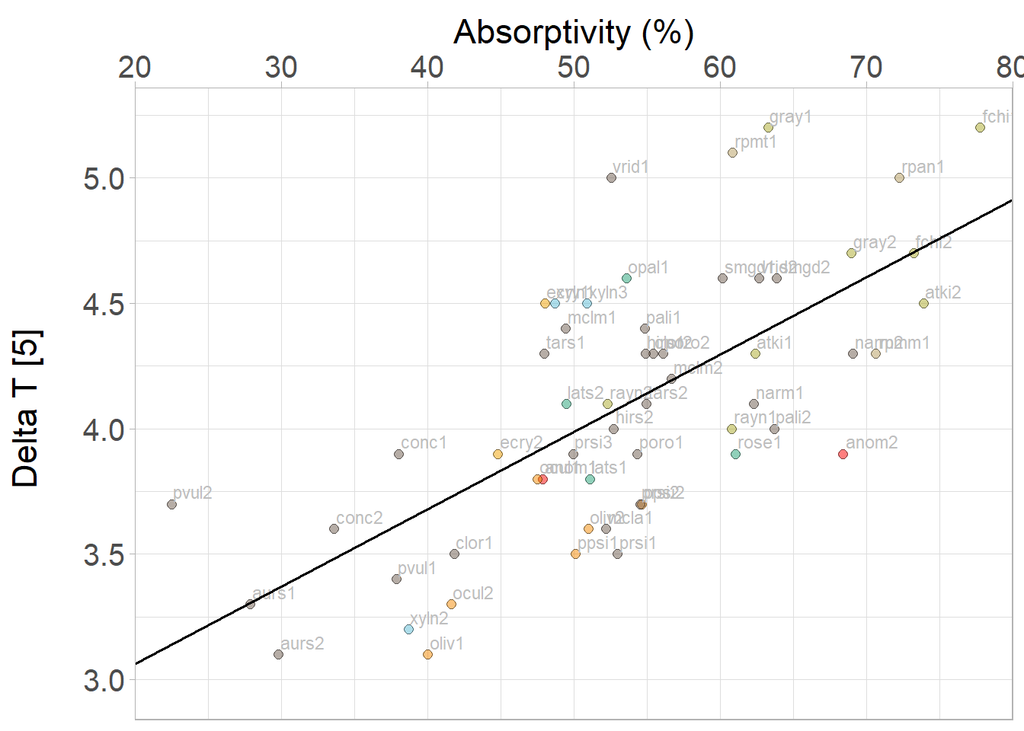

```r
Single <-
  Single %>%
  mutate (genus = SingleElytra$genus)

## Plot Delta Temp 5 min ~ Absorptivity
dummy <- lm(DT5_TOT ~ Ab_TOT, data = Single)

ggplot(Single,aes(Ab_TOT, DT5_TOT, label = Beetle, group = genus))+
  geom_point(aes(fill=genus),alpha=0.5,cex=2,shape=21)+
  theme_light() +
  theme(axis.text.x = element_text(size = 15))+
  theme(axis.text.y = element_text(size = 15))+
  theme(axis.title.x = element_text(size = 17))+
  theme(axis.title.y = element_text(size = 17))+
  theme(axis.title.y = element_text(margin =
                                      margin(t = 0, r = 20, b = 0, l = 0)))+
  labs(x="Absorptivity (%)",y="Delta T [5] ")+
  geom_text(size=3, hjust=-0.05, vjust=-0.4,col="gray")+
  scale_fill_manual(values = wes_palette("Darjeeling1",
                                         n = 8,type = "continuous"))+
  scale_x_continuous(position="top", limits = c(20,80), expand = c(0, 0))+
  scale_y_continuous(limits=c(3, 5.2), expand = c(0.05, 0.05)) +
  theme(legend.position = "none")+
  geom_abline(intercept = dummy$coefficients[1],
              slope = dummy$coefficients[2], col="black",size=0.6)
```

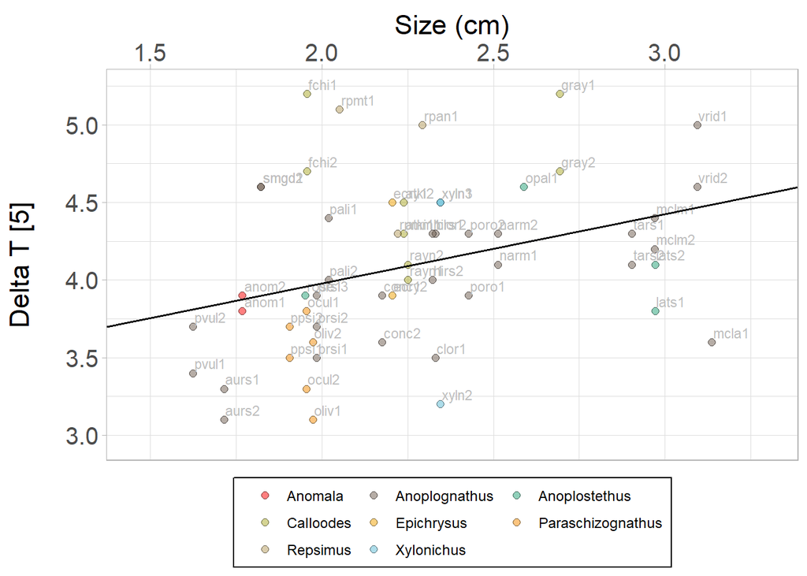

```r
# Plot Delta Temp 5 min ~ Size
dummy2 <- lm(DT5_TOT ~ size , data = Single)

ggplot(Single,aes(size, DT5_TOT, label = Beetle, group = genus))+
  geom_point(aes(fill = genus), alpha = 0.5, cex = 2, shape = 21)+
  theme_light() +
  theme(axis.text.x = element_text(size = 15))+
  theme(axis.text.y = element_text(size = 15))+
  theme(axis.title.x = element_text(size = 17))+
  theme(axis.title.y = element_text(size = 17))+
  theme(axis.title.y = element_text(margin =
                                      margin(t = 0, r = 20, b = 0, l = 0)))+
  labs(x="Size (cm)",y="Delta T [5]")+
  geom_text(size=3, hjust=-0.05, vjust=-0.4,col="gray")+
  scale_fill_manual(values = wes_palette("Darjeeling1",
                                         n = 8,type = "continuous"))+
  scale_x_continuous(position="top", expand = c(0.1, 0.1))+
  scale_y_continuous(limits=c(3, 5.2), expand = c(0.05, 0.05)) +
  geom_abline(intercept = dummy2$coefficients[1],
              slope = dummy2$coefficients[2], col="black",size=0.6)+
  theme(legend.position="bottom")+
  theme(legend.title=element_blank())+
  theme(legend.background = element_rect(colour="black"))+
  theme(legend.key.height = unit(0.4, 'cm'),
        legend.key.width= unit(0.6, 'cm'))+
  guides(fill=guide_legend(nrow=3,byrow=TRUE))+
  theme(legend.text = element_text(size=9))
```

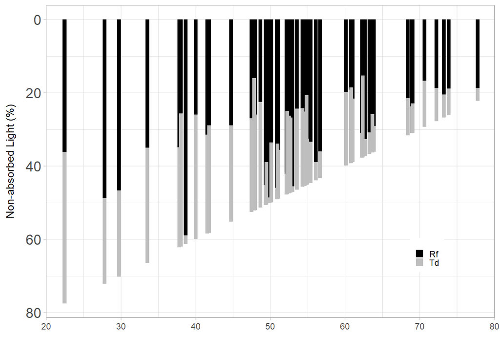

```r
# Barplot

ggplot(Stacked1, aes(AbsTOT, y = TOT))+
  geom_col(aes(fill = optic), width = 0.5,
           position = position_stack(reverse=TRUE))+
  theme_light() +
  scale_x_continuous(limits=c(20, 80), expand = c(0, 0)) +
  scale_y_continuous(limits=c(0, 100), expand = c(0, 0)) +
  theme(legend.position= c(0.85,0.2))+
  theme(legend.title=element_blank())+
  scale_y_reverse()+
  theme(axis.title.y = element_text(margin =
                                      margin(t = 0, r = 10, b = 0, l = 0)))+
  theme(axis.text.y = element_text(size = 14))+
  theme(axis.title.x = element_text(margin =
                                      margin(t = 10, r = 0, b = 0, l = 0)))+
  scale_fill_manual(values = c("black","gray"))+
  labs(x=" ",y=" Non-absorbed Light (%) ")+
  theme(legend.key.height = unit(0.3, 'cm'),
        legend.key.width= unit(0.3, 'cm'))
```

## Figure 3

1. Barplots

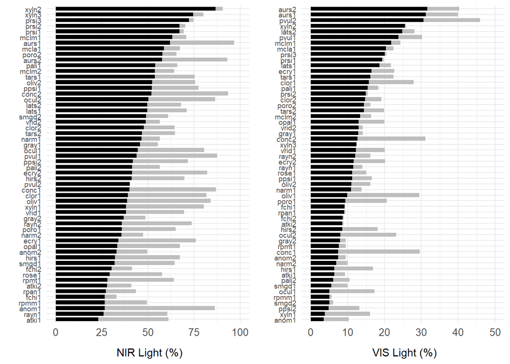

```r
# NIR

bp2<-ggplot(Stacked1, aes(x = reorder (Beetle, NIR_factor, FUN = sum ),
                          y = NIR))+
  geom_col(aes(fill = optic), width = 0.7,
           position = position_stack(reverse=TRUE))+
  coord_flip()+
  theme_minimal()+
  ylim(0,100)+
  scale_fill_manual(values = c("black","gray"))+
  theme(legend.position="none")+
  labs(x=" ",y=" NIR Light (%)")+
  theme(axis.text.y = element_text(size=7))+
  theme(axis.text.x = element_text(size = 10))+
  theme(axis.title.x = element_text(margin =
                                    margin(t = 10, r = 0, b = 0, l = 0)))

# VIS

bp3<-ggplot(Stacked1, aes(x = reorder (Beetle, VIS_factor, FUN = sum ),
                          y = VIS))+
  geom_col(aes(fill = optic), width = 0.7,
           position = position_stack(reverse=TRUE))+
  coord_flip()+
  theme_minimal()+
  ylim(0,50)+
  scale_fill_manual(values = c("black","gray"))+
  theme(legend.position="none")+
  labs(x=" ",y=" VIS Light (%)")+
  theme(axis.text.y = element_text(size=7))+
  theme(axis.text.x = element_text(size = 10))+
  theme(axis.title.x = element_text(margin =
                                      margin(t = 10, r = 0, b = 0, l = 0)))

# Join them

grid.arrange(bp2,bp3,ncol=2)
```

2. Examples of the diversity in optical properties

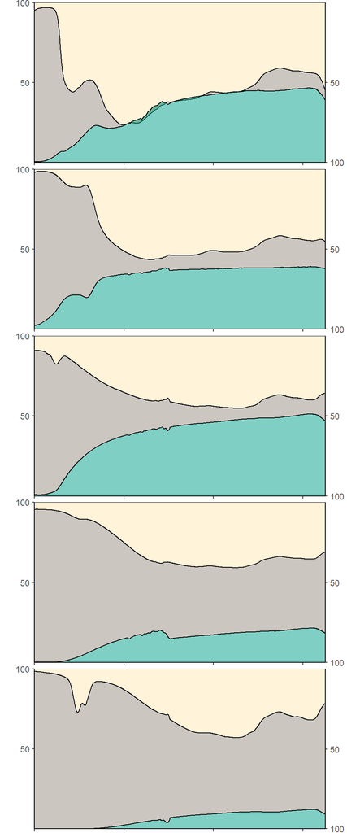

```r
PlotT1B<-ggplot() +
  geom_ribbon(data=Reflect,
              mapping = aes(x = wl, y = 100 - anom2,
                            ymin=TopTrans$anom2t, ymax=100-anom2),
              fill="#b6ada6", alpha=0.7)+

  geom_ribbon(data=Reflect,
              mapping = aes(x = wl, y = 100 - anom2,
                            ymin=100,ymax=100-anom2),
              colour="black", fill="#ffd781", alpha=0.3)+

  geom_area(data = TopTrans,
            aes(x = wl, y = anom2t),
            fill="#00a08a", colour="black", alpha=0.5) +

  scale_x_continuous(limits=c(400, 1700),expand = c(0, 0))+
  scale_y_continuous(limits=c(0, 100),breaks = c(50,100),
                     expand = c(0, 0),
                     sec.axis = sec_axis(~100-.,breaks = c(100,50))) +
  theme_classic()+
  ylab( " " )+
  theme(plot.margin = unit(c(0.1,0.1,0.05,0.1), "cm"))+
  theme(axis.text.x = element_blank())+
  theme(axis.title.x = element_blank())


PlotT2B<-ggplot() +

  geom_ribbon(data=Reflect,
              mapping = aes(x=wl,y=100-fchi1,
                            ymin=TopTrans$fchi1t,ymax=100-fchi1),
              fill="#b6ada6", alpha=0.7)+

  geom_ribbon(data=Reflect,
              mapping = aes(x=wl,y=100-fchi1,
                            ymin=100,ymax=100-fchi1),
              colour="black", fill="#ffd781", alpha=0.3)+

  geom_area(data=TopTrans,
            aes(x=wl, y=fchi1t),
            fill="#00a08a", colour="black", alpha=0.5) +

  scale_x_continuous(limits=c(400, 1700),
                     expand = c(0, 0))+
  scale_y_continuous(limits=c(0, 100),breaks = c(50,100),
                     expand = c(0, 0),
                     sec.axis = sec_axis(~100-.,breaks = c(100,50))) +
  theme_classic()+
  ylab( " " )+
  theme(plot.margin = unit(c(0.1,0.1,0.05,0.1), "cm"))+
  theme(axis.text.x = element_blank())+
  theme(axis.title.x = element_blank())


PlotT3B<-ggplot() +

  geom_ribbon(data=Reflect,
              mapping =aes(x=wl,y=100-ocul2,
                           ymin=TopTrans$ocul2t,ymax=100-ocul2),
              fill="#b6ada6", alpha=0.7)+

  geom_ribbon(data=Reflect,
              mapping = aes(x=wl,y=100-ocul2,
                            ymin=100,ymax=100-ocul2),
              colour="black", fill="#ffd781", alpha=0.3)+

  geom_area(data=TopTrans,
            aes(x=wl, y=ocul2t),
            fill="#00a08a", colour="black", alpha=0.5) +

  scale_x_continuous(limits=c(400, 1700),
                     expand = c(0, 0))+
  scale_y_continuous(limits=c(0, 100),breaks = c(50,100),
                     expand = c(0, 0),
                     sec.axis = sec_axis(~100-.,breaks = c(100,50))) +
  theme_classic()+
  ylab( " " )+
  theme(plot.margin = unit(c(0.1,0.1,0.05,0.1), "cm"))+
  theme(axis.text.x = element_blank())+
  theme(axis.title.x = element_blank())

PlotT4B<-ggplot() +
  geom_ribbon(data=Reflect,
              mapping = aes(x=wl,y=100-aurs1,
                            ymin=TopTrans$aurs1t,ymax=100-aurs1),
              fill="#b6ada6", alpha=0.7)+

  geom_ribbon(data=Reflect,
              mapping = aes(x=wl,y=100-aurs1,
                            ymin=100,ymax=100-aurs1),
              colour="black", fill="#ffd781", alpha=0.3)+

  geom_area(data=TopTrans,
            aes(x=wl, y=aurs1t),
            fill="#00a08a", colour="black", alpha=0.5) +

  scale_x_continuous(limits=c(400, 1700),
                     expand = c(0, 0))+
  scale_y_continuous(limits=c(0, 100), breaks = c(50,100),
                     expand = c(0, 0),
                     sec.axis = sec_axis(~100-.,breaks = c(100,50))) +
  theme_classic()+
  theme(axis.title.x = element_blank())+
  ylab( " " )+
  theme(axis.text.x = element_blank())+
  theme(plot.margin = unit(c(0.1,0.1,0.05,0.1), "cm"))

PlotT5B<-ggplot() +
  geom_ribbon(data=Reflect,
              mapping = aes(x=wl,y=100-clor1,
                            ymin=TopTrans$clor1t,ymax=100-clor1),
              fill="#b6ada6", alpha=0.7)+

  geom_ribbon(data=Reflect,
              mapping = aes(x=wl,y=100-clor1,
                            ymin=100,ymax=100-clor1),
              colour="black", fill="#ffd781", alpha=0.3)+

  geom_area(data=TopTrans, aes(x=wl, y=clor1t),
            fill="#00a08a", colour="black", alpha=0.5) +

  scale_x_continuous(limits=c(400, 1700),
                     expand = c(0, 0))+
  scale_y_continuous(limits=c(0, 100), breaks = c(50,100),
                     expand = c(0, 0),
                     sec.axis = sec_axis(~100-.,breaks = c(100,50))) +
  theme_classic()+
  theme(axis.title.x = element_blank())+
  ylab( " " )+
  theme(axis.text.x = element_blank())+
  theme(plot.margin = unit(c(0.1,0.1,0.04,0.01), "cm"))


plot_grid(PlotT4B, PlotT3B, PlotT5B, PlotT1B, PlotT2B,
          align = "v", nrow=5, ncol=1, rel_widths = c(1, 1))
```

# Beetle Body

## Stats

We used bootstrap due to limited n.

### Body

Thermocouple placed inside the body of the beetle

```r
DT5_ThermoInt
```

| Beetle | PairDifTOT | PairDifNIR | PairDifVIS |
| --- | --- | --- | --- |
| RDB01 | 0.2 | -0.1 | 0.3 |
| RDB02 | -0.4 | -0.2 | 0 |
| RDB03 | -0.4 | -0.2 | 0.1 |
| RDB04 | 0 | 0 | 0 |
| RDB05 | -0.3 | -0.2 | 0.1 |
| RDB06 | -0.4 | -0.3 | 0.1 |
| RDB07 | -0.4 | -0.4 | -0.1 |
| RDB08 | 0.1 | -0.2 | 0.1 |
| RDB09 | -0.4 | -0.1 | 0.1 |
| RDB10 | -0.4 | -0.2 | 0.1 |
| RDB11 | -0.9 | -0.6 | -0.2 |

```r
# TOT
out1<-rep(NA, 1000)
for (ii in 1:1000){
  samp1<-sample(DT5_ThermoInt$PairDifTOT,
                size = length(DT5_ThermoInt$PairDifTOT),
                replace = TRUE)
  out1[ii]<-mean(samp1)
}

out1.sorted <- sort(out1)
ci1 <- round(
    quantile(out1.sorted,c(0.025,0.975), type=7), # Confidence interval
    4)
ci1r <- paste(ci1[1],ci1[2],sep = " : ")


# NIR
out2<-rep(NA, 1000)
for (ii in 1:1000){
  samp2<-sample(DT5_ThermoInt$PairDifNIR,
                size = length(DT5_ThermoInt$PairDifNIR),
                replace = TRUE)
  out2[ii]<-mean(samp2)
}

out2.sorted <- sort(out2)
ci2 <- round(
    quantile(out2.sorted,c(0.025,0.975), type=7),# Confidence interval
    4)
ci2r <- paste(ci2[1],ci2[2],sep = " : ")

# VIS
out3<-rep(NA, 1000)
for (ii in 1:1000){
  samp3<-sample(DT5_ThermoInt$PairDifVIS,
                size = length(DT5_ThermoInt$PairDifVIS),
                replace = TRUE)
  out3[ii]<-mean(samp3)
}

out3.sorted <- sort(out3)
ci3 <- round(
    quantile(out3.sorted,c(0.025,0.975), type=7), # Confidence interval
    4)
ci3r <- paste(ci3[1],ci3[2],sep = " : ")

data.frame(
  "Band" = c("TOT", "NIR", "VIS"),
  "Mean" = round(c(mean(out1), mean(out2), mean(out3)),4),
  "C.I." = as.character(c(ci1r, ci2r, ci3r))
    ) %>%
  kbl() %>%
  kable_paper("hover", full_width = F)
```

| Band | Mean | C.I. |
| --- | --- | --- |
| TOT | -0.2980 | -0.4545 : -0.1273 |
| NIR | -0.2274 | -0.3182 : -0.1364 |
| VIS | 0.0534 | -0.0273 : 0.1273 |

### Under the elytra

Thermocouple placed under the elytra

Control

```r
DT5_ThermoExt
```

| Beetle | PairDifTOT | PairDifNIR | PairDifVIS |
| --- | --- | --- | --- |
| RDB01 | 0.2 | 0 | 0.3 |
| RDB02 | -0.1 | -0.3 | -0.2 |
| RDB03 | -0.7 | -0.4 | -0.2 |
| RDB04 | 0.4 | 0.2 | 0.1 |
| RDB05 | 0.4 | -0.1 | 0.3 |
| RDB06 | 0.4 | 0.2 | 0.1 |
| RDB07 | 0.1 | 0 | -0.1 |
| RDB08 | 0.4 | -0.2 | 0 |
| RDB09 | -0.1 | 0.1 | -0.1 |
| RDB10 | -0.1 | 0 | 0 |
| RDB11 | -0.7 | -0.5 | -0.3 |

```r
# TOT
out5<-rep(NA, 1000)
for (ii in 1:1000){
  samp5<-sample(DT5_ThermoExt$PairDifTOT,
                size = length(DT5_ThermoExt$PairDifTOT),
                replace = TRUE)
  out5[ii]<-mean(samp5)
}

out5.sorted<-sort(out5)
ci5 <- round(
    quantile(out5.sorted,c(0.025,0.975), type=7), # Confidence interval
    4)
ci5r <- paste(ci5[1],ci5[2],sep = " : ")

# NIR
out6<-rep(NA, 1000)
for (ii in 1:1000){
  samp6<-sample(DT5_ThermoExt$PairDifNIR,
                size = length(DT5_ThermoExt$PairDifNIR),
                replace = TRUE)
  out6[ii]<-mean(samp6)
}

out6.sorted<-sort(out6)
ci6 <- round(
    quantile(out6.sorted,c(0.025,0.975), type=7), # Confidence interval
    4)
ci6r <- paste(ci6[1],ci6[2],sep = " : ")


# VIS
out7<-rep(NA, 1000)
for (ii in 1:1000){
  samp7<-sample(DT5_ThermoExt$PairDifVIS,
                size = length(DT5_ThermoExt$PairDifVIS),
                replace = TRUE)
  out7[ii]<-mean(samp7)
}

out7.sorted<-sort(out7)
ci7 <- round(
    quantile(out7.sorted,c(0.025,0.975), type=7), # Confidence interval
    4)
ci7r <- paste(ci7[1],ci7[2],sep = " : ")

data.frame(
  "Band" = c("TOT", "NIR", "VIS"),
  "Mean" = round(c(mean(out1), mean(out2), mean(out3)),4),
  "C.I." = as.character(c(ci5r, ci6r, ci7r))
    ) %>%
  kbl() %>%
  kable_paper("hover", full_width = F)
```

| Band | Mean | C.I. |
| --- | --- | --- |
| TOT | -0.2980 | -0.2184 : 0.2455 |
| NIR | -0.2274 | -0.2182 : 0.0455 |
| VIS | 0.0534 | -0.1182 : 0.1 |

## Figure 4

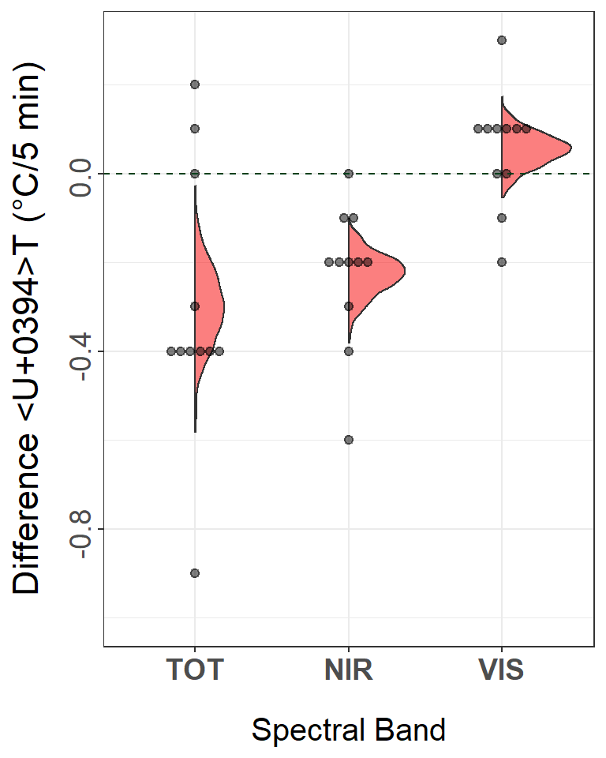

```r
# Prepare Data Sets

BodyDiff <-
  DT5_ThermoInt %>%
  gather (key = B, Difference, -Beetle) %>%
  mutate (Band = substr(B,8,10)) %>%
  select (-B) %>%
  mutate (Band = factor (Band,
                         levels = c("TOT", "NIR", "VIS")) )


BodyBoots <-
  data.frame (out1, out2, out3) %>% # bootstrap results
  rename (TOT = out1,
          NIR = out2,
          VIS = out3) %>%
  gather (key = Band, Difference) %>%
  mutate (Band = factor (Band,
                         levels = c("TOT", "NIR", "VIS")) )



# Package for half violins
source("https://raw.githubusercontent.com/datavizpyr/data/master/half_flat_violinplot.R")

# plot

ggplot(NULL, aes(x = Band, Difference)) +
  geom_flat_violin(data = BodyBoots,
                   fill="#f80000", alpha= 0.5) +
  geom_dotplot(data = BodyDiff,
               binaxis='y', stackdir='center', dotsize=0.5,
               colour="black",fill="black",alpha=0.5)+
  ylim(-1,0.3)+
  theme_bw()+
  geom_hline(yintercept=0, linetype="dashed", color = "#02401b")+
  theme(axis.title.y =
          element_text(size=17,
                       margin = margin(t = 0, r = 10, b = 0, l = 0)))+
  theme(axis.title.x =
          element_text(size=15,
                       margin = margin(t = 15, r = 0, b = 0, l = 0)))+
  theme(axis.text.x=element_text(face="bold",size=14))+
  theme(axis.text.y=element_text(size=14, angle=90, hjust=0.6))+
  labs(y = paste ("Difference ΔT (°C/5 min)"), x = "Spectral Band")
```

# Supplementary Materials

## Light Source

### Figure S1

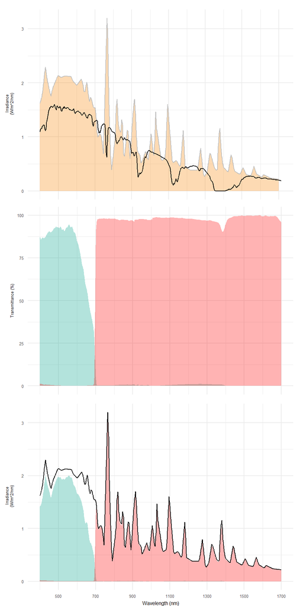

```r
FiltersN <-
  filters %>%
  select (wl, nirfilterTransmittance, visfilterTransmittance) %>%
  gather (key = filters, value = Transm, -wl) %>%
  mutate (Band = substr(filters, 1, 3 ) ) %>%
  select (-filters)

plotS1A <- ggplot() +
  geom_area(aes(x=filters$wl, y=filters$halfsun),
            fill="#F98400", alpha = 0.3) +
  geom_line(aes(x=filters$wl, y=filters$halfsun),
            colour="gray") +
  geom_line(data=theorySun,mapping = aes(x=wl,
                                         y=irradiance))+
  theme_minimal()+
  theme(axis.ticks.x = element_blank(),
        axis.text.x = element_blank(),
        axis.title.x = element_blank())+
  ylab(expression("   Irradiance \n (W/m^2/nm)"))+
  theme(axis.title.y = element_text(size=5),
        axis.text.y = element_text(size=5)) +
  scale_x_continuous(breaks=seq(300,1700,200)) +
  theme(plot.margin = unit(c(0.4, 0.4, 0, 0.4), "cm"))

plotS1B <- ggplot() +
  geom_area(aes(x=FiltersN$wl[FiltersN$Band == "vis"],
                y=FiltersN$Transm[FiltersN$Band == "vis"]),
            fill="#00A08A", alpha = 0.3) +
  geom_area(aes(x=FiltersN$wl[FiltersN$Band =="nir"],
                y=FiltersN$Transm[FiltersN$Band =="nir"]),
            fill="#FF0000", alpha = 0.3)+
  theme_minimal()+
  xlab(" ")+
  ylab("Transmittance (%)")+
  theme(axis.title.y = element_text(size=5),
        axis.text.y = element_text(size=5)) +
  theme(axis.ticks.x = element_blank(),
        axis.text.x = element_blank(),
        axis.title.x = element_blank())+
  scale_x_continuous(breaks=seq(300,1700,200)) +
  theme(plot.margin = unit(c(0.2, 0.4, 0.3, 0.4), "cm"))

plotS1C <- ggplot() +
  geom_area(aes(x=filters$wl, y=filters$vis.f),
            fill="#00A08A", alpha = 0.3) +
  geom_area(aes(x=filters$wl, y=filters$nir.f),
            fill="#FF0000", alpha = 0.3)+
  geom_line(data=filters,mapping = aes(x=wl,
                                       y=Full.f),
            colour="black")+
  theme_minimal()+
  xlab("Wavelength (nm)")+
  ylab(expression("   Irradiance \n (W/m^2/nm)"))+
  theme(axis.title.y = element_text(size=5),
        axis.title.x = element_text(size=6),
        axis.text.y = element_text(size=5),
        axis.text.x = element_text(size=5)) +
  scale_x_continuous(breaks=seq(300,1700,200)) +
  theme(plot.margin = unit(c(0, 0.4, 0, 0.4), "cm"))

plot_grid(plotS1A, plotS1B,plotS1C,
          align = "v", axis = "bt", rel_widths = c(1, 1),
          ncol=1)
```

## Repeatability

### Table

```r
# Delta Temp after 5 min

RepDTdata<-
  Repeatability %>%
  select (spp, DT5_TOT, DT5_NIR, DT5_VIS)

RModelDT_Full <- rpt(DT5_TOT ~ (1 | spp), "spp",
                   data = RepDTdata,
                   nboot = 1000, npermut = 0,
                   datatype = "Gaussian")
```

```
## Bootstrap Progress:
```

```r
summary(RModelDT_Full)
```

```
##
## Repeatability estimation using the lmm method
##
## Call = rpt(formula = DT5_TOT ~ (1 | spp), grname = "spp", data = RepDTdata, datatype = "Gaussian", nboot = 1000, npermut = 0)
##
## Data: 44 observations
## ----------------------------------------
##
## spp (6 groups)
##
## Repeatability estimation overview:
##       R     SE   2.5%  97.5% P_permut  LRT_P
##    0.91  0.103  0.586  0.968       NA      0
##
## Bootstrapping and Permutation test:
##             N   Mean Median   2.5%  97.5%
## boot     1000   0.87  0.903  0.586  0.968
## permut      1     NA     NA     NA     NA
##
## Likelihood ratio test:
## logLik full model = -11.36359
## logLik red. model = -47.50959
## D  = 72.3, df = 1, P = 9.28e-18
##
## ----------------------------------------
```

```r
RModelDT_nir <- rpt(DT5_NIR ~ (1 | spp), "spp",
                  data = RepDTdata,
                  nboot = 1000, npermut = 0,
                  datatype = "Gaussian")
```

```
## Bootstrap Progress:
```

```r
summary(RModelDT_nir)
```

```
##
## Repeatability estimation using the lmm method
##
## Call = rpt(formula = DT5_NIR ~ (1 | spp), grname = "spp", data = RepDTdata, datatype = "Gaussian", nboot = 1000, npermut = 0)
##
## Data: 44 observations
## ----------------------------------------
##
## spp (6 groups)
##
## Repeatability estimation overview:
##       R     SE   2.5%  97.5% P_permut  LRT_P
##   0.795  0.152   0.34  0.923       NA      0
##
## Bootstrapping and Permutation test:
##             N   Mean Median   2.5%  97.5%
## boot     1000  0.741   0.78   0.34  0.923
## permut      1     NA     NA     NA     NA
##
## Likelihood ratio test:
## logLik full model = 0.7551644
## logLik red. model = -20.97594
## D  = 43.5, df = 1, P = 2.16e-11
##
## ----------------------------------------
```

```r
RModelDT_vis <- rpt(DT5_VIS ~ (1 | spp), "spp",
                  data = RepDTdata,
                  nboot = 1000, npermut = 0,
                  datatype = "Gaussian")
```

```
## Bootstrap Progress:
```

```r
summary(RModelDT_vis)
```

```
##
## Repeatability estimation using the lmm method
##
## Call = rpt(formula = DT5_VIS ~ (1 | spp), grname = "spp", data = RepDTdata, datatype = "Gaussian", nboot = 1000, npermut = 0)
##
## Data: 44 observations
## ----------------------------------------
##
## spp (6 groups)
##
## Repeatability estimation overview:
##       R     SE   2.5%  97.5% P_permut  LRT_P
##   0.781  0.149  0.341  0.913       NA      0
##
## Bootstrapping and Permutation test:
##             N   Mean Median   2.5%  97.5%
## boot     1000  0.723  0.761  0.341  0.913
## permut      1     NA     NA     NA     NA
##
## Likelihood ratio test:
## logLik full model = 8.440956
## logLik red. model = -12.25749
## D  = 41.4, df = 1, P = 6.21e-11
##
## ----------------------------------------
```

```r
# Heating Rates

RepHRdata<-
  Repeatability %>%
  select (spp, maxHRTOT, maxHRNIR, maxHRVIS)

RModelHR_Full <- rpt(maxHRTOT ~ (1 | spp), "spp",
                   data = RepHRdata,
                   nboot = 1000, npermut = 0,
                   datatype = "Gaussian")
```

```
## Bootstrap Progress:
```

```r
summary(RModelHR_Full)
```

```
##
## Repeatability estimation using the lmm method
##
## Call = rpt(formula = maxHRTOT ~ (1 | spp), grname = "spp", data = RepHRdata, datatype = "Gaussian", nboot = 1000, npermut = 0)
##
## Data: 44 observations
## ----------------------------------------
##
## spp (6 groups)
##
## Repeatability estimation overview:
##       R     SE   2.5%  97.5% P_permut  LRT_P
##   0.424  0.183 0.0139  0.701       NA  0.001
##
## Bootstrapping and Permutation test:
##             N   Mean Median   2.5%  97.5%
## boot     1000  0.391  0.401 0.0139  0.701
## permut      1     NA     NA     NA     NA
##
## Likelihood ratio test:
## logLik full model = 126.561
## logLik red. model = 122.0428
## D  = 9.04, df = 1, P = 0.00132
##
## ----------------------------------------
```

```r
RModelHR_nir <- rpt(maxHRNIR ~ (1 | spp), "spp",
                   data = RepHRdata,
                   nboot = 1000, npermut = 0,
                   datatype = "Gaussian")
```

```
## Bootstrap Progress:
```

```r
summary(RModelHR_nir)
```

```
##
## Repeatability estimation using the lmm method
##
## Call = rpt(formula = maxHRNIR ~ (1 | spp), grname = "spp", data = RepHRdata, datatype = "Gaussian", nboot = 1000, npermut = 0)
##
## Data: 44 observations
## ----------------------------------------
##
## spp (6 groups)
##
## Repeatability estimation overview:
##       R     SE   2.5%  97.5% P_permut  LRT_P
##   0.637  0.192  0.104  0.849       NA      0
##
## Bootstrapping and Permutation test:
##             N   Mean Median   2.5%  97.5%
## boot     1000  0.569  0.609  0.104  0.849
## permut      1     NA     NA     NA     NA
##
## Likelihood ratio test:
## logLik full model = 162.2648
## logLik red. model = 151.2175
## D  = 22.1, df = 1, P = 1.3e-06
##
## ----------------------------------------
```

```r
RModelHR_vis <- rpt(maxHRVIS ~ (1 | spp), "spp",
                  data = RepHRdata,
                  nboot = 1000, npermut = 0,
                  datatype = "Gaussian")
```

```
## Bootstrap Progress:
```

```r
summary(RModelHR_vis)
```

```
##
## Repeatability estimation using the lmm method
##
## Call = rpt(formula = maxHRVIS ~ (1 | spp), grname = "spp", data = RepHRdata, datatype = "Gaussian", nboot = 1000, npermut = 0)
##
## Data: 44 observations
## ----------------------------------------
##
## spp (6 groups)
##
## Repeatability estimation overview:
##       R     SE   2.5%  97.5% P_permut  LRT_P
##    0.22  0.143      0  0.489       NA   0.06
##
## Bootstrapping and Permutation test:
##             N   Mean Median   2.5%  97.5%
## boot     1000  0.201  0.186      0  0.489
## permut      1     NA     NA     NA     NA
##
## Likelihood ratio test:
## logLik full model = 158.329
## logLik red. model = 157.1193
## D  = 2.42, df = 1, P = 0.0599
##
## ----------------------------------------
```

### Figures

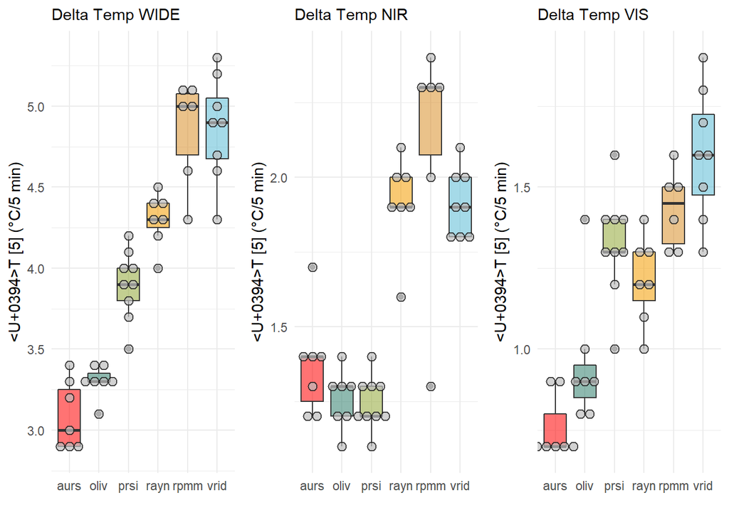

```r
# Delta Temp after 5 min

PlotDTFull<-
  ggplot( aes(x=spp, y=DT5_TOT), data=RepDTdata) +
  geom_boxplot(aes( fill=spp, alpha = 0.5)) +
  geom_dotplot(binaxis='y', stackdir='center', dotsize=0.7,
               colour="black",fill="gray",alpha=0.7)+
  theme_minimal() +
  theme(
    legend.position="none",
    plot.title = element_text(size=11)
  ) +
  ggtitle("Delta Temp WIDE") +
  xlab("") +
  scale_fill_manual(values = wes_palette(
    "Darjeeling1", n = 6,type = "continuous"))+
  ylab("ΔT [5] (°C/5 min)")

PlotDTnir<-
  ggplot( aes(x=spp, y=DT5_NIR), data=RepDTdata) +
  geom_boxplot(aes( fill=spp, alpha = 0.5)) +
  geom_dotplot(binaxis='y', stackdir='center', dotsize=0.7,
               colour="black",fill="gray",alpha=0.7)+
  theme_minimal() +
  theme(
    legend.position="none",
    plot.title = element_text(size=11)
  ) +
  ggtitle("Delta Temp NIR") +
  xlab("") +
  scale_fill_manual(values = wes_palette("Darjeeling1",
                                         n = 6,type = "continuous"))+
  ylab("ΔT [5] (°C/5 min)")

PlotDTvis<-
  ggplot( aes(x=spp, y=DT5_VIS), data=RepDTdata) +
  geom_boxplot(aes( fill=spp, alpha = 0.5)) +
  geom_dotplot(binaxis='y', stackdir='center', dotsize=0.7,
               colour="black",fill="gray",alpha=0.7)+
  theme_minimal() +
  theme(
    legend.position="none",
    plot.title = element_text(size=11)
  ) +
  ggtitle("Delta Temp VIS") +
  xlab("") +
  scale_fill_manual(values = wes_palette("Darjeeling1",
                                         n = 6,type = "continuous"))+
  ylab("ΔT [5] (°C/5 min)")

plot_grid(PlotDTFull, PlotDTnir, PlotDTvis,align = "v",
          nrow=1,ncol=3, rel_widths = c(1, 1))
```

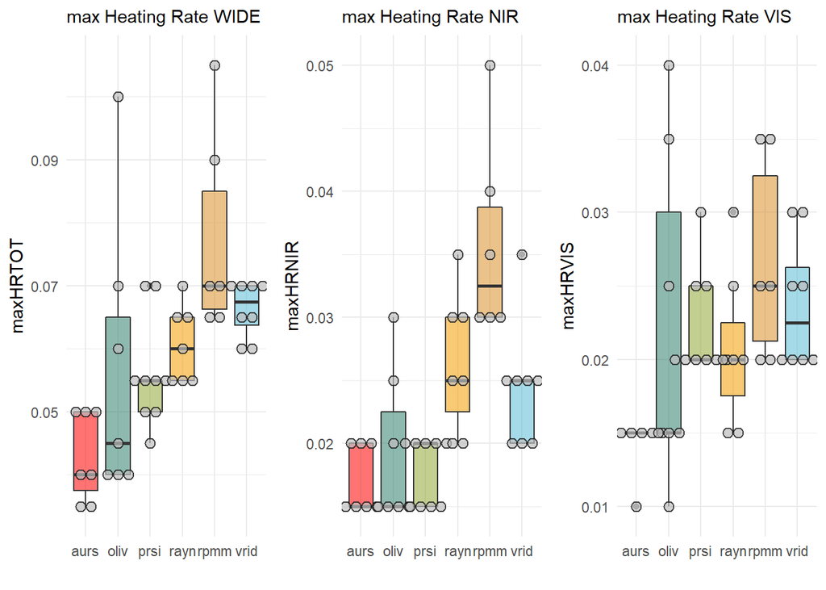

```r
# Heating Rates

PlotHRFull<-
  ggplot( aes(x=spp, y=maxHRTOT), data=RepHRdata) +
  geom_boxplot(aes( fill=spp, alpha = 0.5)) +
  geom_dotplot(binaxis='y', stackdir='center', dotsize=0.7,
               colour="black",fill="gray",alpha=0.7)+
  theme_minimal() +
  theme(
    legend.position="none",
    plot.title = element_text(size=11)
  ) +
  ggtitle("max Heating Rate WIDE") +
  xlab("") +
  scale_fill_manual(values = wes_palette("Darjeeling1",
                                         n = 6,type = "continuous"))

PlotHRnir<-
  ggplot( aes(x=spp, y=maxHRNIR), data=RepHRdata) +
  geom_boxplot(aes( fill=spp, alpha = 0.5)) +
  geom_dotplot(binaxis='y', stackdir='center', dotsize=0.7,
               colour="black",fill="gray",alpha=0.7)+
  theme_minimal() +
  theme(
    legend.position="none",
    plot.title = element_text(size=11)
  ) +
  ggtitle("max Heating Rate NIR") +
  xlab("") +
  scale_fill_manual(values = wes_palette("Darjeeling1",
                                         n = 6,type = "continuous"))

PlotHRvis<-
  ggplot( aes(x=spp, y=maxHRVIS), data=RepHRdata) +
  geom_boxplot(aes( fill=spp, alpha = 0.5)) +
  geom_dotplot(binaxis='y', stackdir='center', dotsize=0.7,
               colour="black",fill="gray",alpha=0.7)+
  theme_minimal() +
  theme(
    legend.position="none",
    plot.title = element_text(size=11)
  ) +
  ggtitle("max Heating Rate VIS") +
  xlab("") +
  scale_fill_manual(values = wes_palette("Darjeeling1",
                                         n = 6,type = "continuous"))

plot_grid(PlotHRFull, PlotHRnir, PlotHRvis,align = "v",
          nrow=1,ncol=3, rel_widths = c(1, 1))
```

## Reflectivity

### Delta T5

```r
# TOTAL
mod1D <- lm(DT5_TOT ~ Rf_TOT + size + side, data = Single)

mod1DPer <- c (
  anova(mod1D)[1,2]/sum(anova(mod1D)[,2])*100,
  anova(mod1D)[2,2]/sum(anova(mod1D)[,2])*100,
  anova(mod1D)[3,2]/sum(anova(mod1D)[,2])*100)

# NIR
mod2D <- lm(DT5_NIR ~ Rf_NIR + size + side, data = Single)

mod2DPer <- c (
  anova(mod2D)[1,2]/sum(anova(mod2D)[,2])*100,
  anova(mod2D)[2,2]/sum(anova(mod2D)[,2])*100,
  anova(mod2D)[3,2]/sum(anova(mod2D)[,2])*100)

# VIS
mod3D <- lm(DT5_VIS ~ Rf_VIS + size + side, data = Single)

mod3DPer <- c (
  anova(mod3D)[1,2]/sum(anova(mod3D)[,2])*100,
  anova(mod3D)[2,2]/sum(anova(mod3D)[,2])*100,
  anova(mod3D)[3,2]/sum(anova(mod3D)[,2])*100)


export_summs(mod1D, mod2D, mod3D,
             error_format = "SE = {std.error} p = {p.value}",
             model.names = c("TOT", "NIR", "VIS"))
```

|  | TOT | NIR | VIS |
| --- | --- | --- | --- |
| (Intercept) | 3.7782 *** | 1.5649 *** | 0.8795 *** |
|  | SE = 0.3530 p = 0.0000 | SE = 0.2110 p = 0.0000 | SE = 0.1341 p = 0.0000 |
| Rf_TOT | -0.0264 *** |  |  |
|  | SE = 0.0059 p = 0.0000 |  |  |
| size | 0.5159 *** | 0.2062 * | 0.2416 *** |
|  | SE = 0.1410 p = 0.0006 | SE = 0.0838 p = 0.0172 | SE = 0.0554 p = 0.0001 |
| sideB | -0.1079 | -0.0227 | -0.1191 * |
|  | SE = 0.1156 p = 0.3548 | SE = 0.0686 p = 0.7422 | SE = 0.0454 p = 0.0114 |
| Rf_NIR |  | -0.0100 *** |  |
|  |  | SE = 0.0025 p = 0.0002 |  |
| Rf_VIS |  |  | -0.0068 * |
|  |  |  | SE = 0.0033 p = 0.0440 |
| N | 56 | 56 | 56 |
| R2 | 0.3876 | 0.2843 | 0.3817 |
| *** p < 0.001; ** p < 0.01; * p < 0.05. |  |  |  |

```r
data.frame( "Var" = c("OpticalProp", "Size", "Side"),
            "TOT" = mod1DPer,
            "NIR" = mod2DPer,
            "VIS" = mod3DPer)  %>%
  kbl() %>%
  kable_paper("hover", full_width = F)
```

| Var | TOT | NIR | VIS |
| --- | --- | --- | --- |
| OpticalProp | 21.11500 | 19.6704960 | 5.200977 |
| Size | 16.62151 | 8.6084900 | 24.787868 |
| Side | 1.02668 | 0.1505468 | 8.181039 |

### maxHR

```r
# TOTAL
mod1E<-lm(maxHRTOT ~ Rf_TOT + size + side, data = Single)

mod1EPer <- c (
anova(mod1E)[1,2]/sum(anova(mod1E)[,2])*100,
anova(mod1E)[2,2]/sum(anova(mod1E)[,2])*100,
anova(mod1E)[3,2]/sum(anova(mod1E)[,2])*100)

# NIR
mod2E<-lm(maxHRNIR ~ Rf_NIR + size + side, data = Single)

mod2EPer <- c (
anova(mod2E)[1,2]/sum(anova(mod2E)[,2])*100,
anova(mod2E)[2,2]/sum(anova(mod2E)[,2])*100,
anova(mod2E)[3,2]/sum(anova(mod2E)[,2])*100)

# VIS
mod3E<-lm(maxHRVIS ~ Rf_VIS + size + side, data = Single)

mod3EPer <- c (
anova(mod3E)[1,2]/sum(anova(mod3E)[,2])*100,
anova(mod3E)[2,2]/sum(anova(mod3E)[,2])*100,
anova(mod3E)[3,2]/sum(anova(mod3E)[,2])*100)


export_summs(mod1E, mod2E, mod3E,
             error_format = "SE = {std.error} p = {p.value} ",
             model.names = c("TOT", "NIR", "VIS"))
```

|  | TOT | NIR | VIS |
| --- | --- | --- | --- |
| (Intercept) | 0.0724 *** | 0.0372 *** | 0.0267 *** |
|  | SE = 0.0112 p = 0.0000 | SE = 0.0043 p = 0.0000 | SE = 0.0054 p = 0.0000 |
| Rf_TOT | -0.0007 *** |  |  |
|  | SE = 0.0002 p = 0.0003 |  |  |
| size | 0.0092 * | -0.0003 | 0.0014 |
|  | SE = 0.0045 p = 0.0439 | SE = 0.0017 p = 0.8776 | SE = 0.0022 p = 0.5319 |
| sideB | -0.0065 | -0.0018 | -0.0050 ** |
|  | SE = 0.0037 p = 0.0792 | SE = 0.0014 p = 0.2148 | SE = 0.0018 p = 0.0081 |
| Rf_NIR |  | -0.0003 *** |  |
|  |  | SE = 0.0001 p = 0.0000 |  |
| Rf_VIS |  |  | -0.0003 * |
|  |  |  | SE = 0.0001 p = 0.0375 |
| N | 56 | 56 | 56 |
| R2 | 0.3173 | 0.3777 | 0.2132 |
| *** p < 0.001; ** p < 0.01; * p < 0.05. |  |  |  |

```r
data.frame( "Var" = c("OpticalProp", "Size", "Side"),
            "TOT" = mod1EPer,
            "NIR" = mod2EPer,
            "VIS" = mod3EPer)  %>%
  kbl() %>%
  kable_paper("hover", full_width = F)
```

| Var | TOT | NIR | VIS |
| --- | --- | --- | --- |
| OpticalProp | 20.987713 | 35.8854246 | 8.779891 |
| Size | 6.534403 | 0.0023255 | 1.057666 |
| Side | 4.209703 | 1.8868104 | 11.487366 |

## Transmissivity

### Delta T5

```r
# TOTAL
mod1F <- lm(DT5_TOT ~ Td_TOT + size + side, data = Single)

mod1FPer <- c (
  anova(mod1F)[1,2]/sum(anova(mod1F)[,2])*100,
  anova(mod1F)[2,2]/sum(anova(mod1F)[,2])*100,
  anova(mod1F)[3,2]/sum(anova(mod1F)[,2])*100)

# NIR
mod2F <- lm(DT5_NIR ~ Td_NIR + size + side, data = Single)

mod2FPer <- c (
  anova(mod2F)[1,2]/sum(anova(mod2F)[,2])*100,
  anova(mod2F)[2,2]/sum(anova(mod2F)[,2])*100,
  anova(mod2F)[3,2]/sum(anova(mod2F)[,2])*100)

# VIS
mod3F <- lm(DT5_VIS ~ Td_VIS + size + side, data = Single)

mod3FPer <- c (
  anova(mod3F)[1,2]/sum(anova(mod3F)[,2])*100,
  anova(mod3F)[2,2]/sum(anova(mod3F)[,2])*100,
  anova(mod3F)[3,2]/sum(anova(mod3F)[,2])*100)


export_summs(mod1F, mod2F, mod3F,
             error_format = "SE = {std.error} p = {p.value}",
             model.names = c("TOT", "NIR", "VIS"))
```

|  | TOT | NIR | VIS |
| --- | --- | --- | --- |
| (Intercept) | 3.7136 *** | 1.3302 *** | 0.9257 *** |
|  | SE = 0.4458 p = 0.0000 | SE = 0.2720 p = 0.0000 | SE = 0.1399 p = 0.0000 |
| Td_TOT | -0.0137 * |  |  |
|  | SE = 0.0067 p = 0.0456 |  |  |
| size | 0.3103 | 0.1394 | 0.2087 *** |
|  | SE = 0.1684 p = 0.0710 | SE = 0.1016 p = 0.1761 | SE = 0.0564 p = 0.0005 |
| sideB | -0.2134 | -0.0696 | -0.1342 ** |
|  | SE = 0.1293 p = 0.1048 | SE = 0.0773 p = 0.3724 | SE = 0.0451 p = 0.0044 |
| Td_NIR |  | -0.0014 |  |
|  |  | SE = 0.0028 p = 0.6059 |  |
| Td_VIS |  |  | -0.0093 * |
|  |  |  | SE = 0.0044 p = 0.0371 |
| N | 56 | 56 | 56 |
| R2 | 0.2174 | 0.0724 | 0.3852 |
| *** p < 0.001; ** p < 0.01; * p < 0.05. |  |  |  |

```r
data.frame( "Var" = c("OpticalProp", "Size", "Side"),
            "TOT" = mod1FPer,
            "NIR" = mod2FPer,
            "VIS" = mod3FPer)  %>%
  kbl() %>%
  kable_paper("hover", full_width = F)
```

| Var | TOT | NIR | VIS |
| --- | --- | --- | --- |
| OpticalProp | 11.614523 | 1.976260 | 9.686435 |
| Size | 6.023813 | 3.814659 | 18.345616 |
| Side | 4.101043 | 1.444339 | 10.484757 |

### maxHR

```r
# TOTAL
mod1G<-lm(maxHRTOT ~ Td_TOT + size + side, data = Single)

mod1GPer <- c (
anova(mod1G)[1,2]/sum(anova(mod1G)[,2])*100,
anova(mod1G)[2,2]/sum(anova(mod1G)[,2])*100,
anova(mod1G)[3,2]/sum(anova(mod1G)[,2])*100)

# NIR
mod2G<-lm(maxHRNIR ~ Td_NIR + size + side, data = Single)

mod2GPer <- c (
anova(mod2G)[1,2]/sum(anova(mod2G)[,2])*100,
anova(mod2G)[2,2]/sum(anova(mod2G)[,2])*100,
anova(mod2G)[3,2]/sum(anova(mod2G)[,2])*100)

# VIS
mod3G<-lm(maxHRVIS ~ Td_VIS + size + side, data = Single)

mod3GPer <- c (
anova(mod3G)[1,2]/sum(anova(mod3G)[,2])*100,
anova(mod3G)[2,2]/sum(anova(mod3G)[,2])*100,
anova(mod3G)[3,2]/sum(anova(mod3G)[,2])*100)


export_summs(mod1G, mod2G, mod3G,
             error_format = "SE = {std.error} p = {p.value} ",
             model.names = c("TOT", "NIR", "VIS"))
```

|  | TOT | NIR | VIS |
| --- | --- | --- | --- |
| (Intercept) | 0.0602 *** | 0.0279 *** | 0.0269 *** |
|  | SE = 0.0141 p = 0.0001 | SE = 0.0060 p = 0.0000 | SE = 0.0058 p = 0.0000 |
| Td_TOT | -0.0001 |  |  |
|  | SE = 0.0002 p = 0.6498 |  |  |
| size | 0.0060 | -0.0013 | 0.0004 |
|  | SE = 0.0053 p = 0.2676 | SE = 0.0022 p = 0.5673 | SE = 0.0023 p = 0.8574 |
| sideB | -0.0090 * | -0.0029 | -0.0056 ** |
|  | SE = 0.0041 p = 0.0322 | SE = 0.0017 p = 0.0978 | SE = 0.0019 p = 0.0041 |
| Td_NIR |  | 0.0000 |  |
|  |  | SE = 0.0001 p = 0.7858 |  |
| Td_VIS |  |  | -0.0002 |
|  |  |  | SE = 0.0002 p = 0.1826 |
| N | 56 | 56 | 56 |
| R2 | 0.1219 | 0.0613 | 0.1733 |
| *** p < 0.001; ** p < 0.01; * p < 0.05. |  |  |  |

```r
data.frame( "Var" = c("OpticalProp", "Size", "Side"),
            "TOT" = mod1GPer,
            "NIR" = mod2GPer,
            "VIS" = mod3GPer)  %>%
  kbl() %>%
  kable_paper("hover", full_width = F)
```

| Var | TOT | NIR | VIS |
| --- | --- | --- | --- |
| OpticalProp | 1.039351 | 0.6815375 | 2.762681 |
| Size | 2.964358 | 0.3180801 | 0.265086 |
| Side | 8.182405 | 5.1295563 | 14.299062 |

## Dorsal/Ventral Transm

### Stats

Difference was calculated as ventral - dorsal / dorsal * 100. So, if the difference is positive, the ventral transmittance would be larger than dorsal.

```r
Tram <-
  Optical %>%
  select (1, 11:13 )


ttestTOT <- t.test(Tram$DifferenceTransTOT,mu=0)
ttestNIR <- t.test(Tram$DifferenceTransNIR,mu=0)
ttestVIS <- t.test(Tram$DifferenceTransVIS,mu=0)

tt1mean <- c(mean(Tram$DifferenceTransTOT),
             mean(Tram$DifferenceTransNIR),
             mean(Tram$DifferenceTransVIS))

tt1tstat <- round (
  c(parse_number(toString(ttestTOT[1])),
    parse_number(toString(ttestNIR[1])),
    parse_number(toString(ttestVIS[1]))), 4)


tt1pval <- round (
  c(parse_number(toString(ttestTOT[3])),
    parse_number(toString(ttestNIR[3])),
    parse_number(toString(ttestVIS[3]))), 4)

tt1CInum <-  round (
  c((ttestTOT[4]$conf.int[1:2]),
    (ttestNIR[4]$conf.int[1:2]),
    (ttestVIS[4]$conf.int[1:2])), 4)

ttCI <- c(
  paste(Cor1CInum[1], Cor1CInum[2], sep = " : " ),
  paste(Cor1CInum[3], Cor1CInum[4], sep = " : " ),
  paste(Cor1CInum[5], Cor1CInum[6], sep = " : " )
)


data.frame (
  "SpectralBand" = c("TOT", "NIR", "VIS"),
  "Mean" = tt1mean,
  "t-stat" = tt1tstat,
  "C.I." = ttCI,
  "p-value" = tt1pval
    ) %>%
  kbl() %>%
  kable_paper("hover", full_width = F)
```

| SpectralBand | Mean | t.stat | C.I. | p.value |
| --- | --- | --- | --- | --- |
| TOT | 10.412575 | 2.8217 | -0.5419 : -0.0682 | 0.0066 |
| NIR | 9.758875 | 2.7390 | -0.6523 : -0.2363 | 0.0083 |
| VIS | 17.979794 | 3.1409 | -0.288 : 0.2374 | 0.0027 |

### Plot

Plot

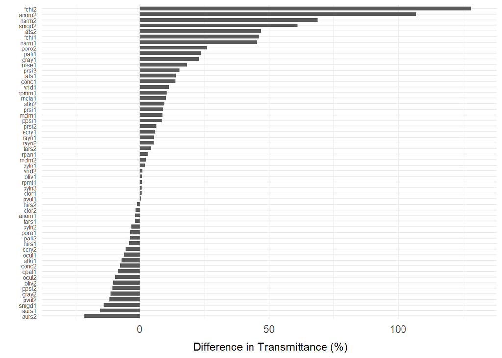

```r
ggplot(Tram, aes(x = reorder (spp, DifferenceTransTOT),
                          y = DifferenceTransTOT))+
  geom_col(aes(), width = 0.7,
           position = position_stack(reverse=TRUE))+
  coord_flip()+
  theme_minimal()+
  ylim(-30,130)+
  theme(legend.position="none")+
  labs(x=" ",y=" Difference in Transmittance (%)")+
  theme(axis.text.y = element_text(size=6))+
  theme(axis.text.x = element_text(size = 10))+
  theme(axis.title.x = element_text(margin =
                                    margin(t = 8, r = 0, b = 0, l = 0)))
```